# Homework #3

Ishita Dutta, Ziyuan Lin, Ruize Xu

February 12 2021

## Problem 1

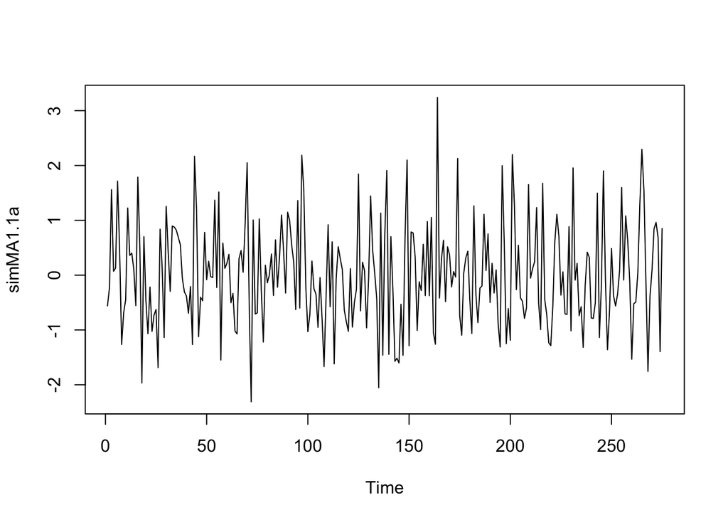

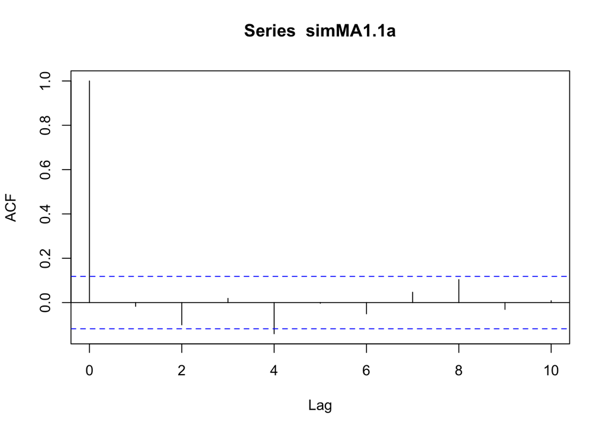

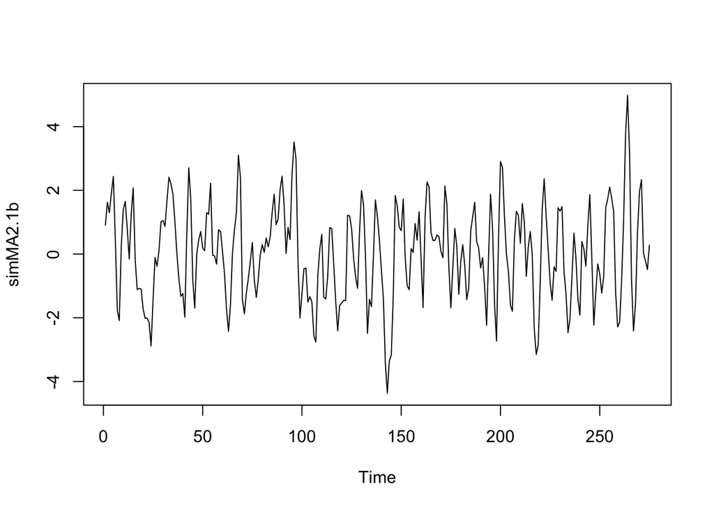

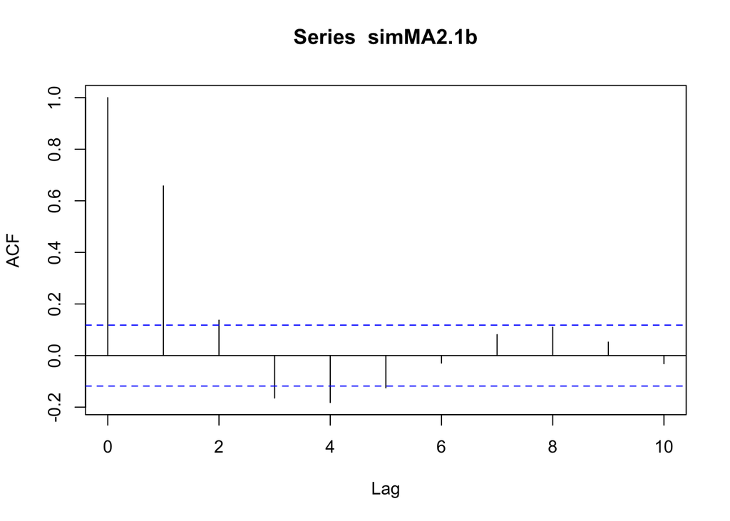

The MA(2) graphs seems to have the wave of the lag much more apparent within the 10 breaks than the MA(1) graph. Essentially, the MA(2) graph has a more coordinated graph on the lag wave than the MA(1), with values closer to the horizontal lines than the MA(1) graph.

## Problem 2

### 2(a)

For MA(1) model:
$$X_t=Z_t+\theta Z_{t-1},\ \ \ where \ \ Z_t\mathop{\sim}\limits^{i.i.d}N(0,\sigma^2).$$

For autocorrelation:
$$\begin{aligned}
\rho(0)&=1\\
\\
\rho(1)&=\frac{\gamma(0)}{\gamma{(1)}}=\frac{\theta}{1+\theta^2}\\
\\
\rho(h)&=0,\ where \ \ \ h\geq 2
\end{aligned}$$

### 2(b)

$$\begin{align}
&Var(\overline{X})=\frac{\tau_n^2}{n}, \ \ \ where \\
\\
&\tau^2_n=\gamma(0)+2\sum_{h=1}^{n-1}(1-\frac{h}{n})\gamma(h)=\gamma(0)+2(1-\frac{1}{n}\gamma(1))=(1+\theta^2)\sigma^2+2\cdot\frac{n-1}{n}\theta\sigma^2=0.3978947\\
\\
&Var(\overline{X})=\frac{\tau_n^2}{n}=0.004188366
\end{align}$$

### 2(c)

When $\theta=0.8$, we get $Var(\overline{X})$=0.2374958.

### 2(d)

95% confidence interval for $\mu=E(X_t)$ is:

$$(\overline{X}-1.96\frac{\tau_n}{\sqrt{n}},\overline{X}+1.96\frac{\tau_n}{\sqrt{n}})$$

## Problem 3

### 3(a)

In the case of AR(1) model, i.e.
$$X_t-\mu=\phi(X_{t-1}-\mu)+\epsilon_t$$
For $\gamma(0)$ and $\rho(h)$:
$$\begin{aligned}
&\gamma(0)=Var(X_t)=(1-\phi^2)^{-1}\sigma^2=19.44444\\
\\
&\rho(h)=\phi^h\\
\\
&\tau_n^2\approx\gamma(0)[1+2\sum_{h=1}^{\infty}\rho(h)]=\sigma^2/(1-\phi)^2=2.160494\\
\\
&Var(\overline{X_t})=\frac{\tau_n^2}{n}=0.02274204
\end{aligned}$$

### 3(b)

When $\phi=0.8$, we get $Var(\overline{X})= 1.842105$.

##4

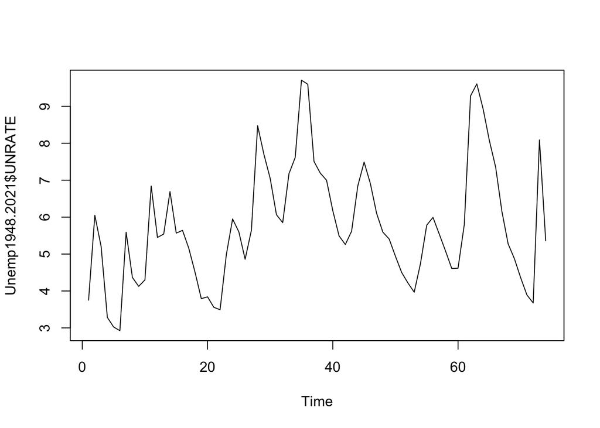

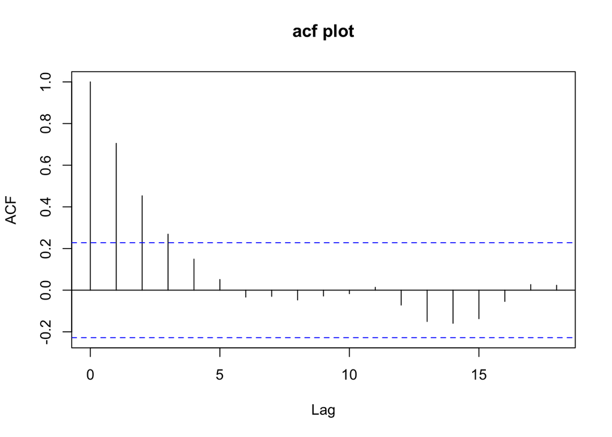

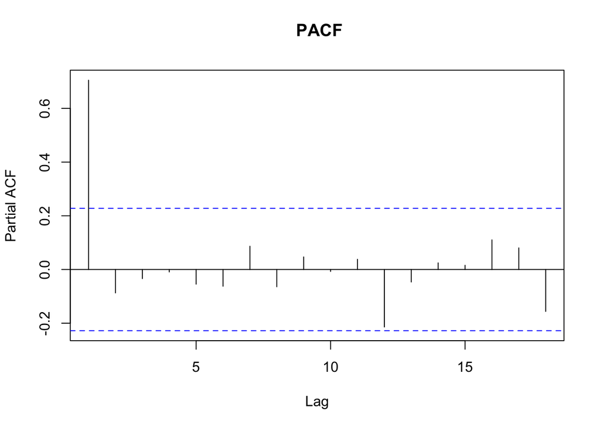

| AR1.aic | AR2.aic | AR3.aic | AR4.aic | AR5.aic | AR6.aic |
| --- | --- | --- | --- | --- | --- |
| 234.5559 | 235.2847 | 237.2512 | 239.1987 | 240.9296 | 242.8016 |

choose AR 1 because smallest AIC value

```
##
## Call:
## arima(x = data, order = c(1, 0, 0))
##
## Coefficients:
##          ar1  intercept
##       0.7113     5.6856
## s.e.  0.0807     0.4407
##
## sigma^2 estimated as 1.273:  log likelihood = -114.28,  aic = 234.56
```

```
##       ar1 intercept
## 0.7112991 5.6855723
```

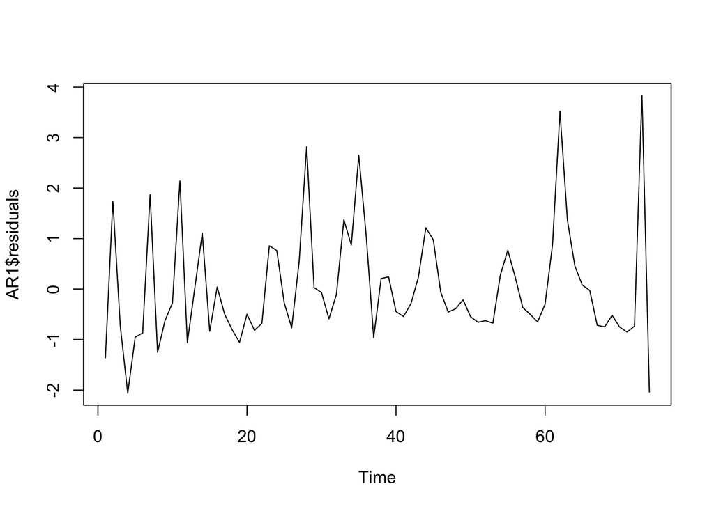

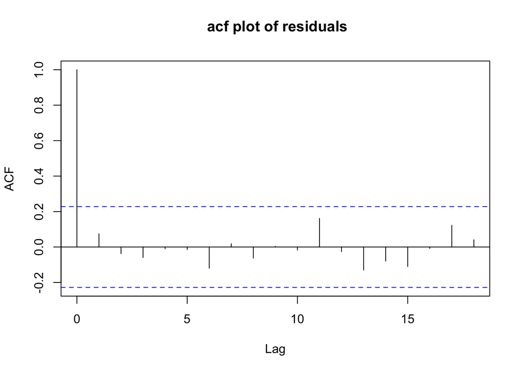

```
##
##  Box-Ljung test
##
## data:  AR1$residuals
## X-squared = 2.4072, df = 10, p-value = 0.9922
```

We do not reject the null hypothesis that residuals are i.i.d. or all the autocorrelations are zero.

```
##  [1] 3.750000 6.050000 5.208333 3.283333 3.025000 2.925000 5.591667 4.366667
##  [9] 4.125000 4.300000 6.841667 5.450000 5.541667 6.691667 5.566667 5.641667
## [17] 5.158333 4.508333 3.791667 3.841667 3.558333 3.491667 4.983333 5.950000
## [25] 5.600000 4.858333 5.641667 8.475000 7.700000 7.050000 6.066667 5.850000
## [33] 7.175000 7.616667 9.708333 9.600000 7.508333 7.191667 7.000000 6.175000
## [41] 5.491667 5.258333 5.616667 6.850000 7.491667 6.908333 6.100000 5.591667
## [49] 5.408333 4.941667 4.500000 4.216667 3.966667 4.741667 5.783333 5.991667
## [57] 5.541667 5.083333 4.608333 4.616667 5.800000 9.283333 9.608333 8.933333
## [65] 8.075000 7.358333 6.158333 5.275000 4.875000 4.358333 3.891667 3.675000
```

| ARn1.aic | ARn2.aic | ARn3.aic | ARn4.aic | ARn5.aic | ARn6.aic |
| --- | --- | --- | --- | --- | --- |
| 213.3339 | 210.2611 | 211.9065 | 213.8531 | 215.4704 | 217.1695 |

we choose AR2 now because smallest aic value

```
##        ar1        ar2  intercept
##  0.9934626 -0.2690977  5.6128301
```

```
##  Hlavac, Marek (2018). stargazer: Well-Formatted Regression and Summary Statistics Tables.
```

```
##  R package version 5.2.2. https://CRAN.R-project.org/package=stargazer
```

```
##
## ==============================================
##                       Dependent variable:
##                   ----------------------------
##                        data         newdata
##                        (1)            (2)
## ----------------------------------------------
## ar1                  0.711***      0.993***
##                      (0.081)        (0.116)
##
## ar2                                -0.269**
##                                     (0.117)
##
## intercept            5.686***      5.613***
##                      (0.441)        (0.412)
##
## ----------------------------------------------
## Observations            74            72
## Log Likelihood       -114.278      -101.131
## sigma2                1.273          0.957
## Akaike Inf. Crit.    234.556        210.261
## ==============================================
## Note:              *p<0.1; **p<0.05; ***p<0.01
```

```
## [1] 4.185842
```

```
## [1] 4.75126
```

```
## $pred
## Time Series:
## Start = 73
## End = 73
## Frequency = 1
## [1] 4.15083
##
## $se
## Time Series:
## Start = 73
## End = 73
## Frequency = 1
## [1] 0.9782596
```

```
## $pred
## Time Series:
## Start = 73
## End = 74
## Frequency = 1
## [1] 4.150830 4.681853
##
## $se
## Time Series:
## Start = 73
## End = 74
## Frequency = 1
## [1] 0.9782596 1.3789533
```

### Code Appendix

```r
knitr::opts_chunk$set(echo = FALSE,warning=FALSE)
library(tidyverse)
library(ggplot2)
#Problem 1(a)
set.seed(123)
simMA1.1a<-arima.sim(n=275,model=list(c(ma=0.7)),sd=1)

plot.ts(simMA1.1a)
acf(simMA1.1a,lag.max = 10)
#Problem 1(b)
set.seed(123)
simMA2.1b<-arima.sim(n=275,model=list(ma=c(1.1,0.7)),sd=1)
plot.ts(simMA2.1b)
acf(simMA2.1b,lag=10)
library(readxl)
Unemp1948.2021 <- read_excel("Unemp1948-2021.xls",skip = 10)
tm <- 1:74
plot1 = plot.ts(Unemp1948.2021$UNRATE)
acf(Unemp1948.2021$UNRATE,main = "acf plot")
pacf(Unemp1948.2021$UNRATE,main = " PACF")
data = Unemp1948.2021$UNRATE
AR1 = arima(data,order = c(1,0,0))
AR2 = arima(data,order = c(2,0,0))
AR3 = arima(data,order = c(3,0,0))
AR4 = arima(data,order = c(4,0,0))
AR5 = arima(data,order = c(5,0,0))
AR6 = arima(data,order = c(6,0,0))
aic_table = data.frame(AR1$aic,AR2$aic,AR3$aic,AR4$aic,AR5$aic,AR6$aic)
aic_table
AR1
AR1$coef
residual_plot = plot(AR1$residuals) # residuals
acf(AR1$residuals, main = " acf plot of residuals")
test <- Box.test(AR1$residuals, lag = 10, type = "Ljung-Box")
test
newdata = Unemp1948.2021$UNRATE[1:72]
newdata
ARn1  = arima(newdata,order = c(1,0,0))
ARn2  = arima(newdata,order = c(2,0,0))
ARn3  = arima(newdata,order = c(3,0,0))
ARn4  = arima(newdata,order = c(4,0,0))
ARn5  = arima(newdata,order = c(5,0,0))
ARn6  = arima(newdata,order = c(6,0,0))
aic_table2 = data.frame(ARn1$aic,ARn2$aic,ARn3$aic,ARn4$aic,ARn5$aic,ARn6$aic)
aic_table2
ARn2$coef
u = mean(newdata)
library(stargazer)
stargazer(AR1,ARn2,type = "text")
forecast_2020 = 0.9927 * (newdata[72]-u) - 0.2691 * (newdata[71] - u) + u
forecast_2020
forecast_2021 = 0.9927 * (forecast_2020-u) -0.2691 * (newdata[72] - u) + u
forecast_2021
predict(ARn2,n.ahead = 1)
predict(ARn2,n.ahead = 2)
```